# Machine Learning Project

AK Patel

6/17/2017

### Introduction

In this project we take the data from 6 participant’s personal activity device while they were asked to perform Unilateral Dumbbell Biceps Curl in 5 different fashion. The first class (Class A) represented the proper execution of the exercise. While the other 4 (Class B thru E) represented common mistakes. Our task was to take the data provided by the personal activity devices and see if we could accurately determine if the individual was performing the exercise correctly, and if not what kind of mistake they were making.

### Load Libraries and Read files

```r
knitr::opts_chunk$set(echo = TRUE)
library(knitr)
library(caret)
```

```r
library(ggplot2)

## load file s## set working environment to desktop
setwd("~/Desktop/Project")

## download files
urlTraining <- "https://d396qusza40orc.cloudfront.net/predmachlearn/pml-training.csv"
urlTesting <- "https://d396qusza40orc.cloudfront.net/predmachlearn/pml-testing.csv"
download.file(urlTraining, destfile = "./training.csv")
download.file(urlTesting, destfile = "./testing.csv")

allTrain <- read.csv("./training.csv", na.strings=c("NA",""),stringsAsFactors = FALSE)
validation <- read.csv("./testing.csv", na.strings=c("NA",""),stringsAsFactors = FALSE)
```

### Cleaning and Data Partition

The data is divided into train, test, and validation set. The train and test data will be used to select the best model. The validation data will be used to determine final model out-of-sample accuracy.

From the data we removed the first 7 columns that are not relevant to our model. We also removed multiple columns in which the data is missing.

```r
## subset files into train, test, and validation
allTrain <- allTrain[,-which(is.na(allTrain[1,]))]
validation <- validation[,-which(is.na(validation[1,]))]
allTrain <- allTrain[,-c(1:7)]
validation <- validation[,-c(1:7)]
inTrain <- createDataPartition(allTrain$classe, p = 0.7, list = FALSE)
training <- allTrain[inTrain, ]
testing <- allTrain[-inTrain, ]

dim(training)
```

```
## [1] 13737    53
```

```r
dim(testing)
```

```
## [1] 5885   53
```

```r
dim(validation)
```

```
## [1] 20 53
```

### Model Building

Again for brevity, we decide to use only 2 models (Decision Tree and Random Forest). Both models are better suited for classification problems where data may not be linear in nature. The Decision Tree is a baseline model that runs quicker than Random Forest, which is highly iterative with multiple sub-sampling. The latter generally performs better in real world accuracy test with a trade-off speed and interpretibility.

### Model Selection

```r
confusionMatrix(predictRPART, testing$classe)
```

```
## Confusion Matrix and Statistics
##
##           Reference
## Prediction    A    B    C    D    E
##          A 1513  475  459  442  156
##          B   37  386   37  163  164
##          C  121  278  530  359  289
##          D    0    0    0    0    0
##          E    3    0    0    0  473
##
## Overall Statistics
##
##                Accuracy : 0.4931
##                  95% CI : (0.4803, 0.506)
##     No Information Rate : 0.2845
##     P-Value [Acc > NIR] : < 2.2e-16
##
##                   Kappa : 0.3377
##  Mcnemar's Test P-Value : NA
##
## Statistics by Class:
##
##                      Class: A Class: B Class: C Class: D Class: E
## Sensitivity            0.9038  0.33889  0.51657   0.0000  0.43715
## Specificity            0.6362  0.91551  0.78452   1.0000  0.99938
## Pos Pred Value         0.4969  0.49047  0.33608      NaN  0.99370
## Neg Pred Value         0.9433  0.85230  0.88487   0.8362  0.88741
## Prevalence             0.2845  0.19354  0.17434   0.1638  0.18386
## Detection Rate         0.2571  0.06559  0.09006   0.0000  0.08037
## Detection Prevalence   0.5174  0.13373  0.26797   0.0000  0.08088
## Balanced Accuracy      0.7700  0.62720  0.65055   0.5000  0.71826
```

```r
confusionMatrix(predictRF, testing$classe)
```

```
## Confusion Matrix and Statistics
##
##           Reference
## Prediction    A    B    C    D    E
##          A 1669   10    0    0    0
##          B    5 1128    5    0    0
##          C    0    0 1019    8    1
##          D    0    1    2  956    2
##          E    0    0    0    0 1079
##
## Overall Statistics
##
##                Accuracy : 0.9942
##                  95% CI : (0.9919, 0.996)
##     No Information Rate : 0.2845
##     P-Value [Acc > NIR] : < 2.2e-16
##
##                   Kappa : 0.9927
##  Mcnemar's Test P-Value : NA
##
## Statistics by Class:
##
##                      Class: A Class: B Class: C Class: D Class: E
## Sensitivity            0.9970   0.9903   0.9932   0.9917   0.9972
## Specificity            0.9976   0.9979   0.9981   0.9990   1.0000
## Pos Pred Value         0.9940   0.9912   0.9912   0.9948   1.0000
## Neg Pred Value         0.9988   0.9977   0.9986   0.9984   0.9994
## Prevalence             0.2845   0.1935   0.1743   0.1638   0.1839
## Detection Rate         0.2836   0.1917   0.1732   0.1624   0.1833
## Detection Prevalence   0.2853   0.1934   0.1747   0.1633   0.1833
## Balanced Accuracy      0.9973   0.9941   0.9957   0.9953   0.9986
```

### Random Forest Model

Some details regarding our model. Of 52 variable used for prediction, we show the ranking of importance of the individual variables in the plot.

```r
print(modRF$finalModel)
```

```
##
## Call:
##  randomForest(x = x, y = y, mtry = param$mtry)
##                Type of random forest: classification
##                      Number of trees: 500
## No. of variables tried at each split: 27
##
##         OOB estimate of  error rate: 0.78%
## Confusion matrix:
##      A    B    C    D    E class.error
## A 3901    2    2    0    1 0.001280082
## B   21 2626   10    1    0 0.012039127
## C    0    9 2377   10    0 0.007929883
## D    0    2   30 2216    4 0.015985790
## E    0    2    4    9 2510 0.005940594
```

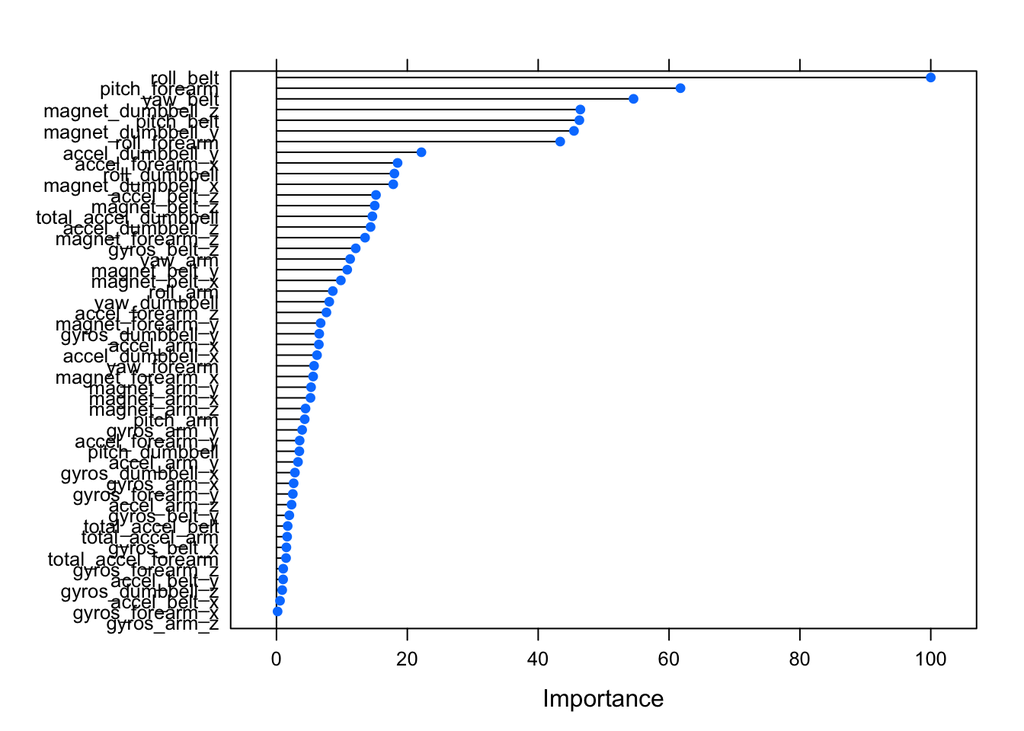

```r
plot(varImp(modRF))
```

### Validation

We use our Random Forest model to test against the validation dataset. The dataset is small, with only 20 observations, hence there is a possibility that we may see slightly lower accuracy than what we observed on our test case.

```r
predictValidation <- predict(modRF, newdata = validation)
predictValidation
```

```
##  [1] B A B A A E D B A A B C B A E E A B B B
## Levels: A B C D E
```

### Acknowledgment

We thankfully acknowledge the following for study parameters and source data: Velloso, E.; Bulling, A.; Gellersen, H.; Ugulino, W.; Fuks, H. Qualitative Activity Recognition of Weight Lifting Exercises. Proceedings of 4th International Conference in Cooperation with SIGCHI (Augmented Human ’13) . Stuttgart, Germany: ACM SIGCHI, 2013. Read more: http://groupware.les.inf.puc-rio.br/har#ixzz4kHN7DIHC